# DT Assignment

# Set 2

In this set we will balance the data by undersampling the majority class (no stroke) to even the data some. This is probably the worst option (but, as the kids say, YOLO), as it is truncating our data. We will randomly sample without replacement to maintain diversity, but ideally we would oversample the minority class, use a nearest neighbors option, or over/under sample in tandem.

After the new data set, it is “rinse, wash, repeat,” so I’ll see you at the model accuracy checks.

```r
factor2<-factor %>%
  group_by(stroke=0)%>%
  slice_sample(n=500, replace=F)

factor3<-factor %>%
  group_by(stroke=1)%>%
  slice_sample(n=300, replace = F)
```

```r
balanced<- rbind(factor2, factor3)
```

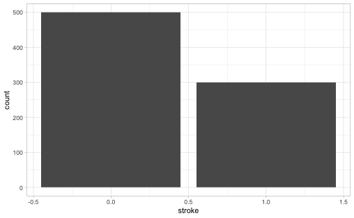

```r
balance_check<-ggplot(balanced, aes(x=stroke, fill=stroke))+geom_bar()+theme_light()
balance_check
```

```r
set.seed(01134)
ind2<-sample(2, nrow(balanced), replace=T, prob = c(0.75,0.25))
train2<-balanced[ind2==1,]
test2<-balanced[ind2==2,]
```

```r
rf2<-randomForest(as.factor(train2$stroke)~.,
                  data=train2, proximity=T)
```

```r
p12<-predict(rf2, train2)
confusionMatrix(p12, as.factor(train2$stroke))
```

```
Confusion Matrix and Statistics

          Reference
Prediction   0   1
         0 367  20
         1   1 213

               Accuracy : 0.9651
                 95% CI : (0.9471, 0.9782)
    No Information Rate : 0.6123
    P-Value [Acc > NIR] : < 2.2e-16

                  Kappa : 0.9253

 Mcnemar's Test P-Value : 8.568e-05

            Sensitivity : 0.9973
            Specificity : 0.9142
         Pos Pred Value : 0.9483
         Neg Pred Value : 0.9953
             Prevalence : 0.6123
         Detection Rate : 0.6106
   Detection Prevalence : 0.6439
      Balanced Accuracy : 0.9557

       'Positive' Class : 0
```

```r
p22<-predict(rf2, test2)
confusionMatrix(p22, as.factor(test2$stroke))
```

```
Confusion Matrix and Statistics

          Reference
Prediction   0   1
         0 109  56
         1  23  11

               Accuracy : 0.603
                 95% CI : (0.5314, 0.6715)
    No Information Rate : 0.6633
    P-Value [Acc > NIR] : 0.9683604

                  Kappa : -0.0115

 Mcnemar's Test P-Value : 0.0003179

            Sensitivity : 0.8258
            Specificity : 0.1642
         Pos Pred Value : 0.6606
         Neg Pred Value : 0.3235
             Prevalence : 0.6633
         Detection Rate : 0.5477
   Detection Prevalence : 0.8291
      Balanced Accuracy : 0.4950

       'Positive' Class : 0
```

Again, we’re losing information in the test set, this is probably because it is too small due to our balancing procedures. This is another example of why undersampling may be inappropriate as we may have not had enough cases to accurately train a model. Over sampling/SMOTE/Over and Under might have been (definitely would have been) a better choice as we could have preserved the entirety of the majority class and had larger train/test data sets. I guess for now, I hope the hospitals use a better algorithm or my doctor is very good!